# 2_Modeling_&_Analysis

### To Do:

1) Based on historical data to build a model which can anticipate “Customer Churn”

2) Out of the build model derive the factors which have the highest impact on predicting “Customer Churn”

3) Focus on those factors mentioned above and perform additional analysis to gain important insights which could be consider when developing customer retention programs

### Parse the data:

```python
#Import possible libraries needed
import pandas as pd, os, numpy as np, seaborn as sns, matplotlib.pyplot as plt
```

```python
plt.style.use('seaborn')
```

```python
df = pd.read_csv('dataset.csv')
```

```python
df.head()
```

|  | customerID | SeniorCitizen | tenure | MonthlyCharges | TotalCharges | encod_gender | encod_Partner | encod_Dependents | encod_PhoneService | encod_MultipleLines | ... | encod_OnlineSecurity | encod_OnlineBackup | encod_DeviceProtection | encod_TechSupport | encod_StreamingTV | encod_StreamingMovies | encod_Contract | encod_PaperlessBilling | encod_PaymentMethod | encod_Churn |
| --- | --- | --- | --- | --- | --- | --- | --- | --- | --- | --- | --- | --- | --- | --- | --- | --- | --- | --- | --- | --- | --- |
| 0 | 7590-VHVEG | 0 | 1 | 29.85 | 29.85 | 0 | 1 | 0 | 0 | 1 | ... | 0 | 2 | 0 | 0 | 0 | 0 | 0 | 1 | 2 | 0 |
| 1 | 5575-GNVDE | 0 | 34 | 56.95 | 1889.50 | 1 | 0 | 0 | 1 | 0 | ... | 2 | 0 | 2 | 0 | 0 | 0 | 1 | 0 | 3 | 0 |
| 2 | 3668-QPYBK | 0 | 2 | 53.85 | 108.15 | 1 | 0 | 0 | 1 | 0 | ... | 2 | 2 | 0 | 0 | 0 | 0 | 0 | 1 | 3 | 1 |
| 3 | 7795-CFOCW | 0 | 45 | 42.30 | 1840.75 | 1 | 0 | 0 | 0 | 1 | ... | 2 | 0 | 2 | 2 | 0 | 0 | 1 | 0 | 0 | 0 |
| 4 | 9237-HQITU | 0 | 2 | 70.70 | 151.65 | 0 | 0 | 0 | 1 | 0 | ... | 0 | 0 | 0 | 0 | 0 | 0 | 0 | 1 | 2 | 1 |

5 rows × 21 columns

```python
df.info()
```

```
<class 'pandas.core.frame.DataFrame'>
RangeIndex: 7032 entries, 0 to 7031
Data columns (total 21 columns):
customerID                7032 non-null object
SeniorCitizen             7032 non-null int64
tenure                    7032 non-null int64
MonthlyCharges            7032 non-null float64
TotalCharges              7032 non-null float64
encod_gender              7032 non-null int64
encod_Partner             7032 non-null int64
encod_Dependents          7032 non-null int64
encod_PhoneService        7032 non-null int64
encod_MultipleLines       7032 non-null int64
encod_InternetService     7032 non-null int64
encod_OnlineSecurity      7032 non-null int64
encod_OnlineBackup        7032 non-null int64
encod_DeviceProtection    7032 non-null int64
encod_TechSupport         7032 non-null int64
encod_StreamingTV         7032 non-null int64
encod_StreamingMovies     7032 non-null int64
encod_Contract            7032 non-null int64
encod_PaperlessBilling    7032 non-null int64
encod_PaymentMethod       7032 non-null int64
encod_Churn               7032 non-null int64
dtypes: float64(2), int64(18), object(1)
memory usage: 1.1+ MB
```

```python
#Checking the classes
#0 --> No; #1 --> Yes
display(np.sum(df.encod_Churn == 0) / len(df))
display(np.sum(df.encod_Churn == 1) / len(df))
```

```
0.7342150170648464
```

```
0.26578498293515357
```

### Findings:

The classes are imbalanced; this could lead to some issues on the model. For now let's move on and we will see how it develops

### Additional Exploration:

```python
#It is possible that some of the numeric variables correlate with each other. This has to be investigated
df[['tenure','TotalCharges','MonthlyCharges']].corr()
```

|  | tenure | TotalCharges | MonthlyCharges |
| --- | --- | --- | --- |
| tenure | 1.000000 | 0.825880 | 0.246862 |
| TotalCharges | 0.825880 | 1.000000 | 0.651065 |
| MonthlyCharges | 0.246862 | 0.651065 | 1.000000 |

### Findings:

- Indeed as you can see "tenure" and "Totalcharges" are pretty hight correlated. Intuitively this makes sense.
- The same thing between "MonthlyCharges" and "Totalcharges".
- Based on the above findings I would take out the variable "TotalCharges"

```python
#Let's store the original parsed data into a new df in case it is needed later
original_df = df.copy()
```

```python
#Dropping "Totalcharges"
df = df.drop(columns=['TotalCharges']).copy()
```

### Preprocessing:

We had already encoded the categorical values, now we would want to assure that our numeric values have a similar scale

```python
from sklearn.preprocessing import MinMaxScaler
```

```python
scaler = MinMaxScaler()
```

```python
scaled_features = scaler.fit_transform(df[['tenure','MonthlyCharges']])
```

```python
scaled_features = \
pd.DataFrame(scaled_features,columns=['scaled_tenure','scaled_MonthlyCharges'])
```

```python
#Since we had already saved all the information on "original_df" we would then proceed now to replace the non-scaled values
a = ['tenure','MonthlyCharges']
b = ['scaled_tenure','scaled_MonthlyCharges']

for i,j in zip(a,b):
    df[a] = scaled_features[b]
```

```python
#checking
df.head()
```

|  | customerID | SeniorCitizen | tenure | MonthlyCharges | encod_gender | encod_Partner | encod_Dependents | encod_PhoneService | encod_MultipleLines | encod_InternetService | encod_OnlineSecurity | encod_OnlineBackup | encod_DeviceProtection | encod_TechSupport | encod_StreamingTV | encod_StreamingMovies | encod_Contract | encod_PaperlessBilling | encod_PaymentMethod | encod_Churn |
| --- | --- | --- | --- | --- | --- | --- | --- | --- | --- | --- | --- | --- | --- | --- | --- | --- | --- | --- | --- | --- |
| 0 | 7590-VHVEG | 0 | 0.000000 | 0.115423 | 0 | 1 | 0 | 0 | 1 | 0 | 0 | 2 | 0 | 0 | 0 | 0 | 0 | 1 | 2 | 0 |
| 1 | 5575-GNVDE | 0 | 0.464789 | 0.385075 | 1 | 0 | 0 | 1 | 0 | 0 | 2 | 0 | 2 | 0 | 0 | 0 | 1 | 0 | 3 | 0 |
| 2 | 3668-QPYBK | 0 | 0.014085 | 0.354229 | 1 | 0 | 0 | 1 | 0 | 0 | 2 | 2 | 0 | 0 | 0 | 0 | 0 | 1 | 3 | 1 |
| 3 | 7795-CFOCW | 0 | 0.619718 | 0.239303 | 1 | 0 | 0 | 0 | 1 | 0 | 2 | 0 | 2 | 2 | 0 | 0 | 1 | 0 | 0 | 0 |
| 4 | 9237-HQITU | 0 | 0.014085 | 0.521891 | 0 | 0 | 0 | 1 | 0 | 1 | 0 | 0 | 0 | 0 | 0 | 0 | 0 | 1 | 2 | 1 |

### Modeling:

Now we are ready to start modeling First we would give it a try to a random forest classifier. Let's see what happens :)

```python
#Let's start with a random forest
from sklearn.model_selection import train_test_split
from sklearn.ensemble import RandomForestClassifier
from sklearn.metrics import accuracy_score, recall_score, precision_score, roc_curve, roc_auc_score, f1_score
```

```python
#Get the iv
X = df[df.columns[1:-1]]
```

```python
#Get the dv
y =df[df.columns[-1]]
```

```python
#Split the data
X_train, X_test, y_train, y_test = train_test_split(X, y, test_size=0.3, stratify=y ,random_state=111,shuffle=True)
```

```python
#Instantiate the random forest
rf =RandomForestClassifier(n_estimators=100, random_state=111)
```

```python
#Train the model
rf.fit(X_train,y_train)
```

```
RandomForestClassifier(bootstrap=True, class_weight=None, criterion='gini',
                       max_depth=None, max_features='auto', max_leaf_nodes=None,
                       min_impurity_decrease=0.0, min_impurity_split=None,
                       min_samples_leaf=1, min_samples_split=2,
                       min_weight_fraction_leaf=0.0, n_estimators=100,
                       n_jobs=None, oob_score=False, random_state=111,
                       verbose=0, warm_start=False)
```

```python
#Predict on Test data
y_pred = rf.predict(X_test)
```

```python
#Let's check on the metrics:
a = ['accuracy_score', 'precision_score','recall_score','f1_score']
b = [accuracy_score, precision_score,recall_score,f1_score]

for i,j in zip(a,b):
    display(i + ': ' + str(j(y_test,y_pred)))
```

```
'accuracy_score: 0.7781990521327015'
```

```
'precision_score: 0.6142506142506142'
```

```
'recall_score: 0.44563279857397503'
```

```
'f1_score: 0.5165289256198347'
```

```python
#Confusion Matrix:
pd.crosstab(y_test, y_pred, rownames=['Actual'], colnames=['Predicted'], margins=True)
```

| Predicted Actual | 0 | 1 | All |
| --- | --- | --- | --- |
| 0 | 1392 | 157 | 1549 |
| 1 | 311 | 250 | 561 |
| All | 1703 | 407 | 2110 |

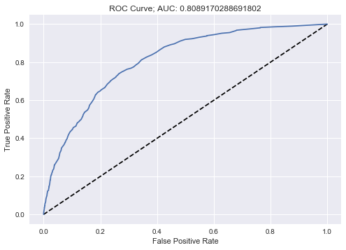

```python
#Let's check the "Receiver Operating Characteristic"

# Compute predicted probabilities: y_pred_prob
y_pred_prob = rf.predict_proba(X_test)[:,1]

# Generate ROC curve values: fpr, tpr, thresholds
fpr, tpr, thresholds = roc_curve(y_test, y_pred_prob)

# Plot ROC curve
plt.plot([0, 1], [0, 1], 'k--')
plt.plot(fpr, tpr)
plt.xlabel('False Positive Rate')
plt.ylabel('True Positive Rate')
plt.title('ROC Curve; '+ 'AUC: ' + str(roc_auc_score(y_test,y_pred_prob)))
plt.show()
```

### Findings:

The accuracy is fair enough,the ROC Curve is acceptable;nevertheless trying to improve the accuracy should not be the primary goal here, then:

- The classes are imbalanced
- The "recall" might the focus here since we do not want clients to go away (we want to be sure of predicting real "positives")

Due to findings above we might want to focus on increasing the recall keeping in mind a good AUC Score

### Feature Importance:

Since we already tried a RF let's make use of its build-in function to be get some more insights when it comes to the feature importance

```python
importances = pd.Series(data=rf.feature_importances_,
                        index= X_train.columns)

importances_sorted = importances.sort_values()
```

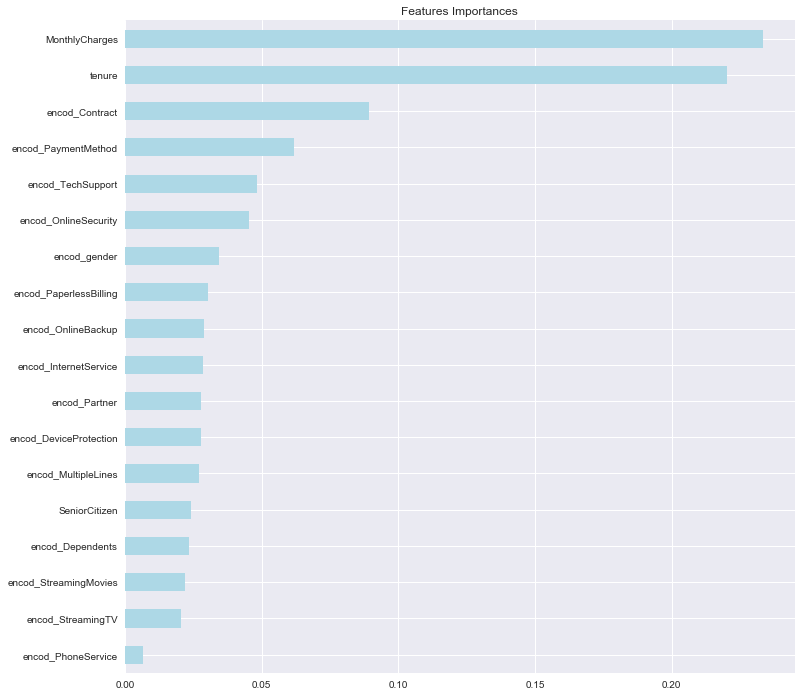

```python
plt.figure(figsize=(12,12))
importances_sorted.plot(kind='barh', color='lightblue')
plt.title('Features Importances')
plt.show()
```

### Findings:

- A lot of features and it seems like only 3-4 of them are able to explain the variable of interest (Churn)

Before we go more in detail here, we are going to try a different algorithm and see if it can outperform the RF

### Trying a new algorithm:

(Logistic Regression):

```python
from sklearn.linear_model import LogisticRegression
```

```python
lr = LogisticRegression(solver='liblinear').fit(X_train, y_train)
```

```python
lr_pred = lr.predict(X_test)
```

```python
#Metrics:
a = ['accuracy_score', 'precision_score','recall_score','f1_score']
b = [accuracy_score, precision_score, recall_score,f1_score]

for i,j in zip(a,b):
    display(i + ': ' + str(j(y_test,lr_pred)))
```

```
'accuracy_score: 0.7981042654028436'
```

```
'precision_score: 0.6477024070021882'
```

```
'recall_score: 0.5276292335115864'
```

```
'f1_score: 0.581532416502947'
```

```python
pd.crosstab(y_test, lr_pred, rownames=['Actual'], colnames=['Predicted'], margins=True)
```

| Predicted Actual | 0 | 1 | All |
| --- | --- | --- | --- |
| 0 | 1388 | 161 | 1549 |
| 1 | 265 | 296 | 561 |
| All | 1653 | 457 | 2110 |

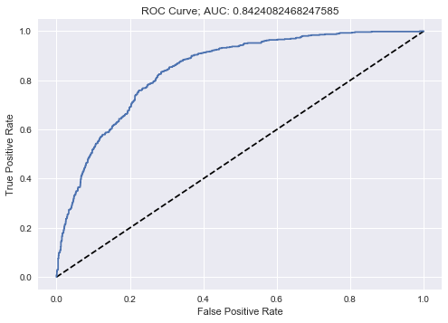

```python
# Compute predicted probabilities: y_pred_prob
y_pred_prob = lr.predict_proba(X_test)[:,1]

# Generate ROC curve values: fpr, tpr, thresholds
fpr, tpr, thresholds = roc_curve(y_test, y_pred_prob)

# Plot ROC curve
plt.plot([0, 1], [0, 1], 'k--')
plt.plot(fpr, tpr)
plt.xlabel('False Positive Rate')
plt.ylabel('True Positive Rate')
plt.title('ROC Curve; '+ 'AUC: ' + str(roc_auc_score(y_test,y_pred_prob)))
plt.show()
```

### Findings:

Based on this findings we might want to go with the Logistic Regression. Just before that we are going to tackle down class imbalance problem.

### Tackling down the imbalance problem:

For this we are going to upsample the classes containing the minority of classes

```python
from sklearn.utils import resample
```

```python
#Upsampling
# concatenate the training data back together
X_Upsampling = pd.concat([X_train, y_train], axis=1)
```

```python
# separate minority and majority classes

not_churn = X_Upsampling[X_Upsampling.encod_Churn == 0]

churn = X_Upsampling[X_Upsampling.encod_Churn ==1]
```

```python
#Generate upsampled matrix
upsampled = \
resample(churn,
         replace=True, # sample with replacement
         n_samples=len(not_churn), # match number in majority class
         random_state=11) # reproducible results
```

```python
#Bring together both classes
upsampled_2 = pd.concat([not_churn,upsampled])
```

```python
#Check correctness
upsampled_2.encod_Churn.value_counts()
```

```
1    3614
0    3614
Name: encod_Churn, dtype: int64
```

### Modeling Again:

(After upsampling)

```python
#split the train dataset (again)
y_train = upsampled_2.encod_Churn
X_train = upsampled_2.drop('encod_Churn', axis=1)

upsampled_lr = LogisticRegression(solver='liblinear').fit(X_train, y_train)

upsampled_pred = upsampled_lr.predict(X_test)
```

```python
#Metrics:
a = ['accuracy_score', 'precision_score','recall_score','f1_score']
b = [accuracy_score, precision_score, recall_score,f1_score]

for i,j in zip(a,b):
    display(i + ': ' + str(j(y_test,upsampled_pred)))
```

```
'accuracy_score: 0.7507109004739336'
```

```
'precision_score: 0.5203252032520326'
```

```
'recall_score: 0.7985739750445633'
```

```
'f1_score: 0.630098452883263'
```

```python
pd.crosstab(y_test, upsampled_pred, rownames=['Actual'], colnames=['Predicted'], margins=True)
```

| Predicted Actual | 0 | 1 | All |
| --- | --- | --- | --- |
| 0 | 1136 | 413 | 1549 |
| 1 | 113 | 448 | 561 |
| All | 1249 | 861 | 2110 |

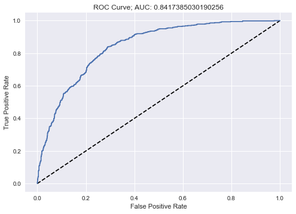

```python
# Compute predicted probabilities: y_pred_prob
y_pred_prob = upsampled_lr.predict_proba(X_test)[:,1]

# Generate ROC curve values: fpr, tpr, thresholds
fpr, tpr, thresholds = roc_curve(y_test, y_pred_prob)

# Plot ROC curve
plt.plot([0, 1], [0, 1], 'k--')
plt.plot(fpr, tpr)
plt.xlabel('False Positive Rate')
plt.ylabel('True Positive Rate')
plt.title('ROC Curve; '+ 'AUC: ' + str(roc_auc_score(y_test,y_pred_prob)))
plt.show()
```

### Findings:

Next we are going to try to improve our model by doing hyperparameter tuning

```python
from sklearn.model_selection import GridSearchCV
```

```python
#Hyperparameters
penalty = ['l1', 'l2']
c_space = np.logspace(-5, 8, 15)
```

```python
param_grid = {'C': c_space, 'penalty': penalty}
```

```python
lreg = LogisticRegression(solver='liblinear')
```

```python
lr_cv = GridSearchCV(lreg,param_grid,cv=5,scoring='roc_auc')
```

```python
lr_cv.fit(X_train,y_train)
```

```
GridSearchCV(cv=5, error_score='raise-deprecating',
             estimator=LogisticRegression(C=1.0, class_weight=None, dual=False,
                                          fit_intercept=True,
                                          intercept_scaling=1, l1_ratio=None,
                                          max_iter=100, multi_class='warn',
                                          n_jobs=None, penalty='l2',
                                          random_state=None, solver='liblinear',
                                          tol=0.0001, verbose=0,
                                          warm_start=False),
             iid='warn', n_jobs=None,
             param_grid={'C': array([1.00000000e-05, 8.48342898e-05, 7.19685673e-04, 6.10540230e-03,
       5.17947468e-02, 4.39397056e-01, 3.72759372e+00, 3.16227766e+01,
       2.68269580e+02, 2.27584593e+03, 1.93069773e+04, 1.63789371e+05,
       1.38949549e+06, 1.17876863e+07, 1.00000000e+08]),
                         'penalty': ['l1', 'l2']},
             pre_dispatch='2*n_jobs', refit=True, return_train_score=False,
             scoring='roc_auc', verbose=0)
```

```python
print("Tuned Logistic Regression Parameter: {}".format(lr_cv.best_params_))
```

```
Tuned Logistic Regression Parameter: {'C': 0.4393970560760795, 'penalty': 'l1'}
```

### Modeling Again:

(After Model-tuning)

```python
#Let's concentrate on the 3 most important features
importances_sorted.sort_values(ascending=False)
```

```
MonthlyCharges            0.233338
tenure                    0.220354
encod_Contract            0.089131
encod_PaymentMethod       0.061802
encod_TechSupport         0.048453
encod_OnlineSecurity      0.045474
encod_gender              0.034541
encod_PaperlessBilling    0.030376
encod_OnlineBackup        0.028806
encod_InternetService     0.028636
encod_Partner             0.027871
encod_DeviceProtection    0.027734
encod_MultipleLines       0.027111
SeniorCitizen             0.024035
encod_Dependents          0.023397
encod_StreamingMovies     0.021894
encod_StreamingTV         0.020429
encod_PhoneService        0.006616
dtype: float64
```

```python
X_train_New = X_train[['tenure', 'MonthlyCharges','encod_Contract']].copy()
```

```python
X_test_New = X_test[['tenure', 'MonthlyCharges','encod_Contract']].copy()
```

```python
lr_cv.best_estimator_.fit(X_train_New,y_train)
```

```
LogisticRegression(C=0.4393970560760795, class_weight=None, dual=False,
                   fit_intercept=True, intercept_scaling=1, l1_ratio=None,
                   max_iter=100, multi_class='warn', n_jobs=None, penalty='l1',
                   random_state=None, solver='liblinear', tol=0.0001, verbose=0,
                   warm_start=False)
```

```python
y_pred_best = lr_cv.best_estimator_.predict(X_test_New)
```

```python
#Metrics:
a = ['accuracy_score', 'precision_score','recall_score','f1_score']
b = [accuracy_score, precision_score, recall_score,f1_score]

for i,j in zip(a,b):
    display(i + ': ' + str(j(y_test,y_pred_best)))
```

```
'accuracy_score: 0.7336492890995261'
```

```
'precision_score: 0.4994535519125683'
```

```
'recall_score: 0.8146167557932263'
```

```
'f1_score: 0.6192411924119241'
```

```python
CM = pd.crosstab(y_test,y_pred_best, rownames=['Actual'], colnames=['Predicted'], margins=True)
CM
```

| Predicted Actual | 0 | 1 | All |
| --- | --- | --- | --- |
| 0 | 1091 | 458 | 1549 |
| 1 | 104 | 457 | 561 |
| All | 1195 | 915 | 2110 |

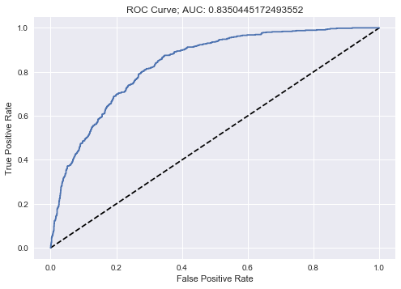

```python
# Compute predicted probabilities: y_pred_prob
y_pred_prob = lr_cv.best_estimator_.predict_proba(X_test_New)[:,1]

# Generate ROC curve values: fpr, tpr, thresholds
fpr, tpr, thresholds = roc_curve(y_test, y_pred_prob)

# Plot ROC curve
plt.plot([0, 1], [0, 1], 'k--')
plt.plot(fpr, tpr)
plt.xlabel('False Positive Rate')
plt.ylabel('True Positive Rate')
plt.title('ROC Curve; '+ 'AUC: ' + str(roc_auc_score(y_test,y_pred_prob)))
plt.show()
```

### Findings:

Looks like we have found what we wanted: An acceptable "recall" as well as an acceptable "AUC Score"

### Additional Analysis of the Features:

(Point 3 of our "To-Do" List)

### Creating Functions:

- Using bootstrapping we would be able to replicate existing values
- This replications would help to generate normal distributions (Central Limit Theorem) and confindence intervals

```python
def bootstrap_sample(data,func):

    bs_sample = np.random.choice(data,len(data))
    return func(bs_sample)
```

```python
def replication(data):

    bs_replicate = np.empty(5000)

    for i in range(5000):
        bs_replicate[i] = bootstrap_sample(data, np.mean)

    return (
            np.percentile(bs_replicate,2.5), # 0
            np.round(np.mean(bs_replicate)), #1,
            np.percentile(bs_replicate,97.5), #2
            bs_replicate #3
            )
```

```python
#Convert the series of Tenure and MonthlyCharges in matrices
LeavingTenure = original_df[original_df.encod_Churn == 1]['tenure'].values
LeavingChargesMonthly = original_df[original_df.encod_Churn == 1]['MonthlyCharges'].values
```

```python
#Apply the replication functions on tenure
testTenure = replication(LeavingTenure)[3]
```

```python
#Apply the replication functions on MonthlyCharge
testChargesMonthly = replication(LeavingChargesMonthly)[3]
```

```python
#Store the results on a df:
results =\
pd.DataFrame({'Tenure': testTenure,'MonthlyCharges': testChargesMonthly})
```

```
lowest pct: 17.0
mean: 18.0
highest pct: 19.0
```

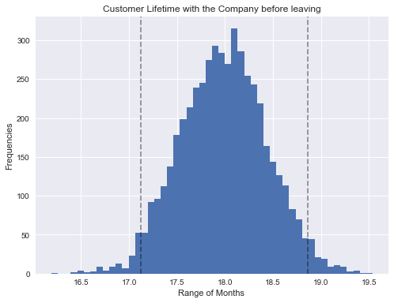

```python
#Visualize Tenure

_ = plt.figure(figsize=(8,6))
_ = plt.hist(testTenure, bins=50)
_ = plt.title('Customer Lifetime with the Company before leaving')
_ = plt.xlabel('Range of Months ')
_ = plt.ylabel('Frequencies')
_ = plt.axvline(np.quantile(testTenure,0.025),color='k',linestyle='--', alpha=0.4)
_ = plt.axvline(np.quantile(testTenure,0.975),color='k',linestyle='--', alpha=0.4)



print('lowest pct: ' + str(np.round(np.quantile(testTenure,0.025))))
print('mean: ' + str(np.round(np.mean(testTenure))))
print('highest pct: ' + str(np.round(np.quantile(testTenure,0.975))))

plt.show()
```

### Findings:

```
73.0
74.0
76.0
```

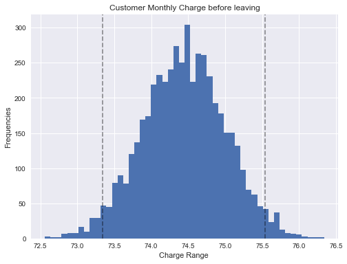

```python
#Visualize Monthly Charges
_ = plt.figure(figsize=(8,6))
_ = plt.hist(testChargesMonthly, bins=50)
_ = plt.title('Customer Monthly Charge before leaving')
_ = plt.xlabel('Charge Range ')
_ = plt.ylabel('Frequencies')
_ = plt.axvline(np.quantile(testChargesMonthly,0.025),color='k',linestyle='--', alpha=0.4)
_ = plt.axvline(np.quantile(testChargesMonthly,0.975),color='k',linestyle='--',alpha=0.4)


print(np.round(np.quantile(testChargesMonthly,0.025)))
print(np.round(np.mean(testChargesMonthly)))
print(np.round(np.quantile(testChargesMonthly,0.975)))
plt.show()
```

### Findings:

```python
#Type of Contract simulation:
```

```python
from scipy.stats import mode
```

```python
myArray = df[df.encod_Churn == 1]['encod_Contract'].values
```

```python
mode_ = []
count_ = []
for i in range(5000):
    x = bootstrap_sample(myArray,mode)
    mode_.append(x.mode[0])
    count_.append(x.count[0])
```

```python
ContractMode = pd.DataFrame({'Mode': mode_, 'Count': count_})
```

```python
ContractMode.groupby(['Mode']).mean()
```

| Mode | Count |
| --- | --- |
| 0 | 1654.775 |

```python
ContractMode.groupby(['Mode']).mean()['Count'][0] / len(myArray)
```

```
0.8853798822899946
```

### Findings:

- It looks like the contract used most of the time for churn clients is "Month to Month"

Nevertheless we need to inspect this on the current data

```python
#Current Data:
```

```python
df[df.encod_Churn == 1]['encod_Contract'].value_counts()
```

```
0    1655
1     166
2      48
Name: encod_Contract, dtype: int64
```

```python
#Get only data where we have a positive churn
a = df[df.encod_Churn == 1]['encod_Contract'].value_counts()
```

```python
#Calculate the percentages per each contract
perc_0 = np.round(a[0] / len(df[df.encod_Churn == 1]),2)
perc_1 = np.round(a[1] / len(df[df.encod_Churn == 1]),2)
perc_2 = np.round(a[2] / len(df[df.encod_Churn == 1]),2)
```

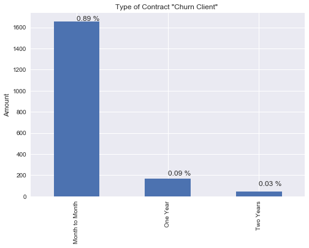

```python
#Visualize:
a.plot.bar()
plt.title('Type of Contract "Churn Client" ')
plt.ylabel('Amount')
plt.xticks([0,1,2],['Month to Month','One Year','Two Years'])
plt.text(0,1665,str(perc_0) + " %",fontsize=12)
plt.text(1,200,str(perc_1) + " %",fontsize=12)
plt.text(2,100,str(perc_2) + " %",fontsize=12)
plt.show()
```

### Findings:

- Same as previous findings

### Next Steps:

- we will perform the same analyis on the same features but for the cases where the churn is negative

```python
#Type of contract negative churn
```

```python
df[df.encod_Churn == 0]['encod_Contract'].value_counts()
```

```
0    2220
2    1637
1    1306
Name: encod_Contract, dtype: int64
```

```python
b = df[df.encod_Churn == 0]['encod_Contract'].value_counts()
```

```python
perc_b0 = np.round(b[0] / len(df[df.encod_Churn == 0]),2)
perc_b1 = np.round(b[1] / len(df[df.encod_Churn == 0]),2)
perc_b2 = np.round(b[2] / len(df[df.encod_Churn == 0]),2)
```

[figure not shown]

```python
#Visualize
b.plot.bar()
plt.title('Type of Contract "Non Churn Client" ')
plt.ylabel('Amount')
plt.xticks([0,1,2],['Month to Month','One Year','Two Years'])
plt.text(0,2240,str(perc_b0) + " %",fontsize=12)
plt.text(1,1660,str(perc_b1) + " %",fontsize=12)
plt.text(2,1350,str(perc_b2) + " %",fontsize=12)
plt.show()
```

### Findings:

A much better balance between the contracts

```python
#Now the same for the numeric variables:
```

```python
#Tenure and Chargesmonthly for negatives Churn
NotLeavingTenure = original_df[original_df.encod_Churn == 0]['tenure'].values
NotLeavingChargesMonthly = original_df[original_df.encod_Churn == 0]['MonthlyCharges'].values
```

```python
#Replications
NotestTenure = replication(NotLeavingTenure)[3]
NotestChargesMonthly = replication(NotLeavingChargesMonthly)[3]
```

```python
Notresults =\
pd.DataFrame({'Tenure': NotestTenure, 'MonthlyCharges': NotestChargesMonthly})
```

```python
Notresults.head()
```

|  | Tenure | MonthlyCharges |
| --- | --- | --- |
| 0 | 37.181484 | 62.317558 |
| 1 | 38.033701 | 61.567858 |
| 2 | 37.537091 | 61.309868 |
| 3 | 37.556653 | 61.735967 |
| 4 | 36.990316 | 62.062735 |

```python
#Now we will bring the Churn and the Non Churn dataframes together but first we must labeled them
results['Churn'] = 'Churn'
results.head()
```

|  | Tenure | MonthlyCharges | Churn |
| --- | --- | --- | --- |
| 0 | 16.905832 | 74.503986 | Churn |
| 1 | 18.080257 | 75.365623 | Churn |
| 2 | 17.761370 | 74.818673 | Churn |
| 3 | 17.535581 | 74.511477 | Churn |
| 4 | 17.838416 | 73.807598 | Churn |

```python
Notresults['Churn'] = 'Not Churn'
Notresults.head()
```

|  | Tenure | MonthlyCharges | Churn |
| --- | --- | --- | --- |
| 0 | 37.181484 | 62.317558 | Not Churn |
| 1 | 38.033701 | 61.567858 | Not Churn |
| 2 | 37.537091 | 61.309868 | Not Churn |
| 3 | 37.556653 | 61.735967 | Not Churn |
| 4 | 36.990316 | 62.062735 | Not Churn |

```python
#Bringing them together:
allresults = pd.concat([results,Notresults],ignore_index=True)
```

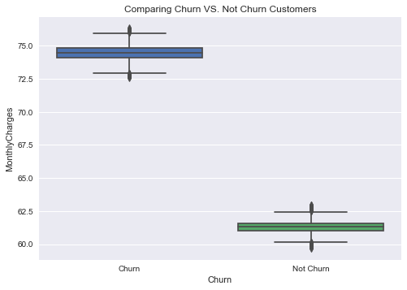

```python
#Visualize and compare
plt.title('Comparing Churn VS. Not Churn Customers')
sns.boxplot(x="Churn", y="MonthlyCharges", data=allresults, saturation=1)
```

```python
#Let get the key metrics for churn and not churn
NotChurnMonthlyChargeKeyMetrics = pd.DataFrame(Notresults.MonthlyCharges.describe())
ChurnMonthlyChargeKeyMetrics = pd.DataFrame(results.MonthlyCharges.describe())
```

```python
#Let's take the counts and std out (The term standard deviation tends to confuse some clients)
NotChurnMonthlyChargeKeyMetrics = NotChurnMonthlyChargeKeyMetrics.drop(['count','std'],axis=0)
```

```python
NotChurnMonthlyChargeKeyMetrics.columns = ['Not Churn']
```

```python
ChurnMonthlyChargeKeyMetrics = ChurnMonthlyChargeKeyMetrics.drop(['count','std'],axis=0)
```

```python
ChurnMonthlyChargeKeyMetrics.columns = ['Churn']
```

```python
ChurnMonthlyChargeKeyMetrics.merge(NotChurnMonthlyChargeKeyMetrics, left_index=True, right_index=True,how='inner')
```

|  | Churn | Not Churn |
| --- | --- | --- |
| mean | 74.444388 | 61.302228 |
| min | 72.560701 | 59.652896 |
| 25% | 74.064573 | 61.009517 |
| 50% | 74.453879 | 61.299458 |
| 75% | 74.822425 | 61.591277 |
| max | 76.340235 | 62.984069 |

### Final Thoughts will be entered on ppt presentation

```python
#Get the current payments for non churn clients
print(np.quantile(Notresults.MonthlyCharges, 0.025))
print(np.mean(Notresults.MonthlyCharges))
print(np.quantile(Notresults.MonthlyCharges, 0.975))
```

```
60.4601484117761
61.302228010846456
62.16363185163665
```